# Assignment 9

Janessa McIlnay

April 13, 2025

## Introduction

In this report, I will analyze predictors of graduate school admissions! The dataset includes:

- `admit`: Admission outcome (1 = admitted, 0 = not admitted)
- `gre`: GRE score
- `gpa`: Undergraduate GPA
- `rank`: Rank of the undergraduate institution (1 = highest)

Let’s set up!

```r
library(tidyverse)
library(easystats)
library(caret)

grad <- read.csv('GradSchool_Admissions.csv')
```

## Analyzing the Data

Let’s see how the data is structured and change it if needed!

```r
str(grad)
```

```
## 'data.frame':    400 obs. of  4 variables:
##  $ admit: int  0 1 1 1 0 1 1 0 1 0 ...
##  $ gre  : int  380 660 800 640 520 760 560 400 540 700 ...
##  $ gpa  : num  3.61 3.67 4 3.19 2.93 3 2.98 3.08 3.39 3.92 ...
##  $ rank : int  3 3 1 4 4 2 1 2 3 2 ...
```

```r
as.logical(grad$admit)
```

[output not shown]

[output cut: 19 more lines]

Okay, let’s make some models to see how the data works!

```r
mod1 <- glm(data = grad,
            formula = admit ~ gre + gpa,
            family = 'binomial')
mod2 <- glm(data = grad,
            formula = admit ~ (gre + gpa)*rank,
            family = 'binomial')
mod3 <- glm(data = grad,
            formula = admit ~ gre*gpa*rank,
            family = 'binomial')
```

Great, now lets see how they do!

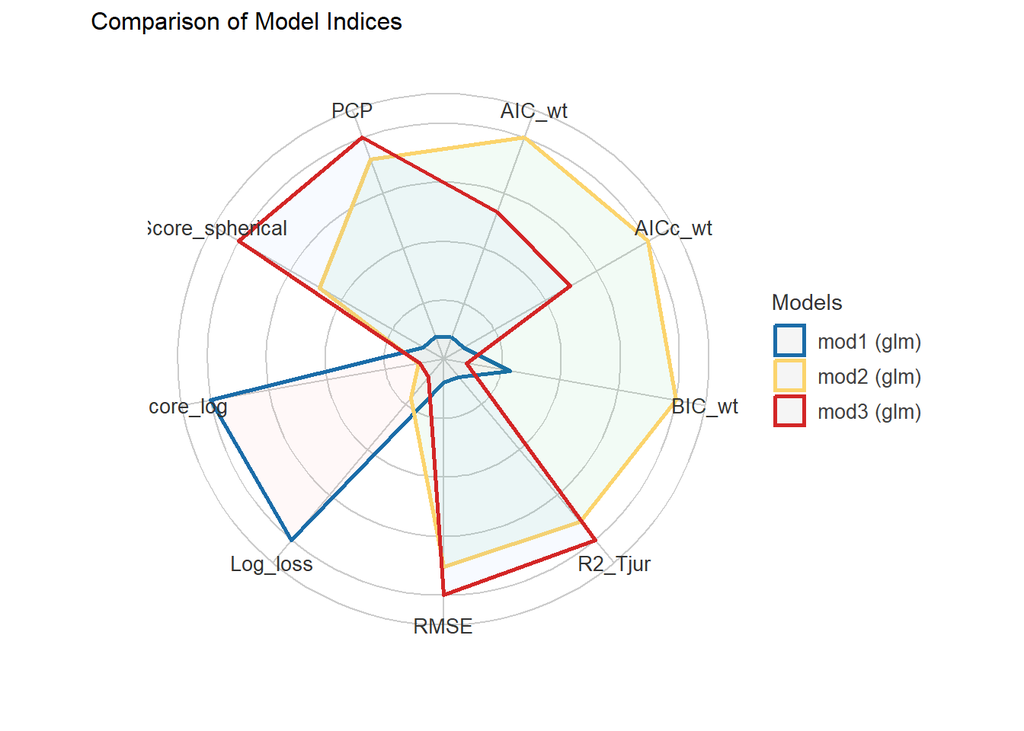

```r
compare_performance(mod1, mod2, mod3) %>% plot()
```

Hmmm, it looks like they are all not doing great at finding correlation between variables. Let’s try again.

```r
# Admission rate by rank
admission_by_rank <- grad %>%
  group_by(rank) %>%
  summarise(admit_rate = mean(admit), count = n())
print(admission_by_rank)
```

```
## # A tibble: 4 × 3
##    rank admit_rate count
##   <int>      <dbl> <int>
## 1     1      0.541    61
## 2     2      0.358   151
## 3     3      0.231   121
## 4     4      0.179    67
```

It looks like people with a rank of ‘1’ get admitted most often. Let’s make some more plots.

# Visualizing the Data

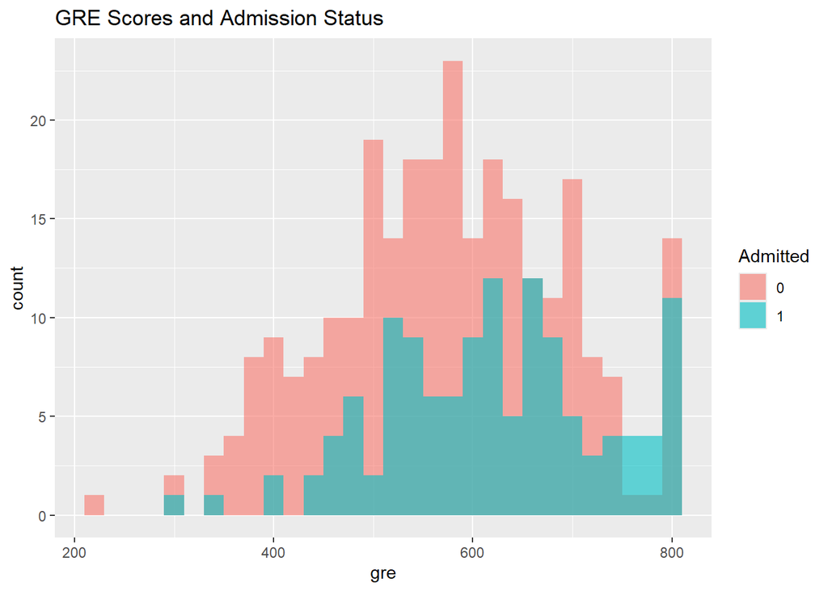

```r
ggplot(grad, aes(x = gre, fill = as.factor(admit))) +
  geom_histogram(position = "identity", alpha = 0.6, bins = 30) +
  labs(title = "GRE Scores and Admission Status", fill = "Admitted")
```

This graph shows that most individuals who are admitted to graduate school seem to have a gre between 500-700.

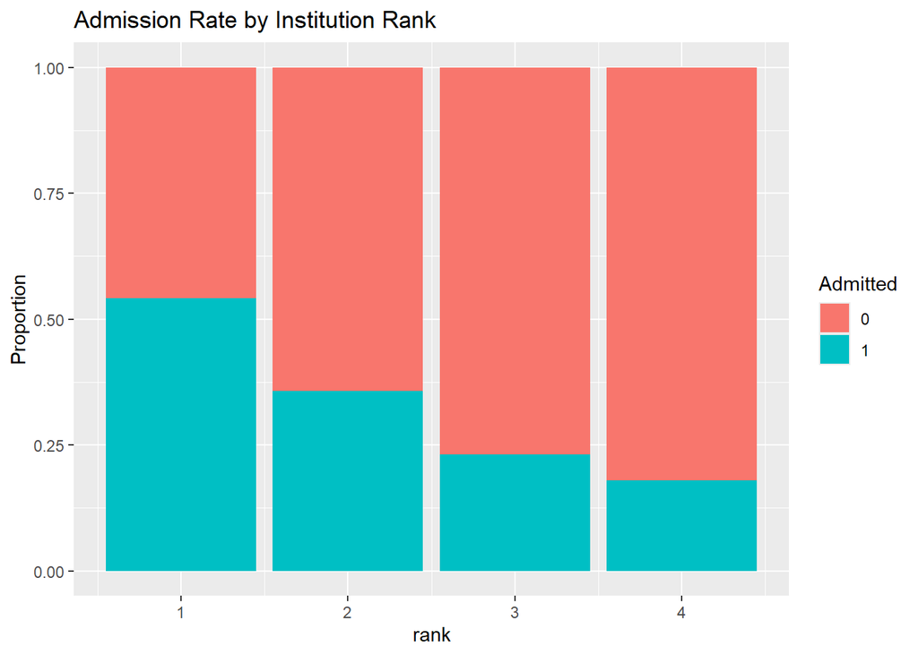

```r
ggplot(grad, aes(x = rank, fill = as.factor(admit))) +
  geom_bar(position = "fill") +
  labs(title = "Admission Rate by Institution Rank", fill = "Admitted") +
  ylab("Proportion")
```

In this graph, it seems that higher ranking individuals are admitted more than those of a lower rank. Let’s make one last graph to see how GPA affects admission.

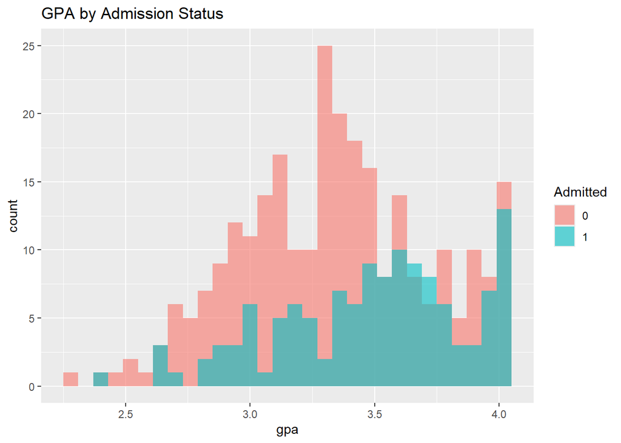

```r
ggplot(grad, aes(x = gpa, fill = as.factor(admit))) +
  geom_histogram(position = "identity", alpha = 0.6, bins = 30) +
  labs(title = "GPA by Admission Status", fill = "Admitted")
```

It seems as though there is not a clear correlation between GPA and admission, however, those with a GPA around 3.5-4.0 seem to be admitted most often.

## Model Fitting: Logistic Regression

```r
# Split data
set.seed(123)
trainIndex <- createDataPartition(grad$admit, p = .8, list = FALSE)
train <- grad[trainIndex, ]
test <- grad[-trainIndex, ]

# Fit logistic regression
model <- glm(admit ~ gre + gpa + rank, data = train, family = "binomial")
summary(model)
```

```
##
## Call:
## glm(formula = admit ~ gre + gpa + rank, family = "binomial",
##     data = train)
##
## Coefficients:
##              Estimate Std. Error z value Pr(>|z|)
## (Intercept) -3.902465   1.295547  -3.012 0.002593 **
## gre          0.001736   0.001233   1.408 0.159262
## gpa          1.009121   0.374564   2.694 0.007057 **
## rank        -0.555749   0.143268  -3.879 0.000105 ***
## ---
## Signif. codes:  0 '***' 0.001 '**' 0.01 '*' 0.05 '.' 0.1 ' ' 1
##
## (Dispersion parameter for binomial family taken to be 1)
##
##     Null deviance: 403.57  on 319  degrees of freedom
## Residual deviance: 370.74  on 316  degrees of freedom
## AIC: 378.74
##
## Number of Fisher Scoring iterations: 3
```

This looks confusing, but it is actually very helpful for understanding the data. Let’s break it down!

Gre is NOT statistically significant, as the p value is 0.16. This means it cannot be used to predict admission. Rank has a negative coefficient, meaning that having a lower rank hurts chances of admission. Additionally, the positive gpa coefficient shows that having a high gpa increases one’s chances of acceptance.

So…gpa and rank are significant admission predictors.

## New Model

```r
mod4 <- glm(data = grad,
            formula = admit ~ rank * gpa,
            family = 'binomial')
summary(mod4)
```

```
##
## Call:
## glm(formula = admit ~ rank * gpa, family = "binomial", data = grad)
##
## Coefficients:
##             Estimate Std. Error z value Pr(>|z|)
## (Intercept)  -3.7164     2.9443  -1.262    0.207
## rank         -0.2171     1.1994  -0.181    0.856
## gpa           1.2697     0.8532   1.488    0.137
## rank:gpa     -0.1062     0.3472  -0.306    0.760
##
## (Dispersion parameter for binomial family taken to be 1)
##
##     Null deviance: 499.98  on 399  degrees of freedom
## Residual deviance: 463.84  on 396  degrees of freedom
## AIC: 471.84
##
## Number of Fisher Scoring iterations: 4
```

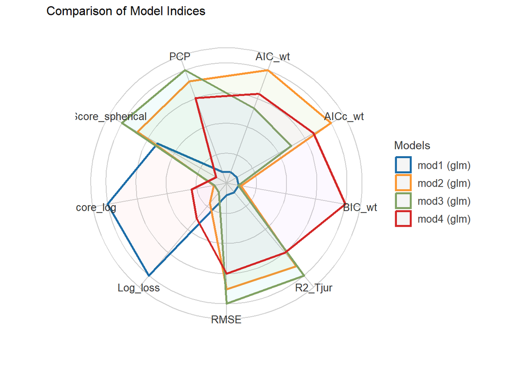

```r
compare_performance(mod1, mod2, mod3, mod4) %>% plot
```